# Lab 4: Spatial Predictive Analysis

Analyzing 311 Violations

Author

Johnny

Published

April 27, 2026

## Step 1: Choose Your 311 Violation Type

### Getting the Data

https://data.cityofchicago.org/Service-Requests/311-Service-Requests-Vacant-and-Abandoned-Building/7nii-7srd/about_data

I chose Vacant and Abandoned Building Reports as the focus of this analysis because it is relatively easy to understand and easier to interpret than some other 311 request types. At the beginning, I expected this pattern to be related to factors such as neighborhood economic conditions and the age of the housing stock. Based on that assumption, I use this project to examine the spatial distribution of vacant and abandoned building reports across Chicago and to explore whether their pattern shows clear clustering and neighborhood differences.

## Step 2: Complete the Analysis

Using the class exercise as your template, adapt the code to analyze your chosen 311 violation type.

### What to Include

Work through all major sections of the analysis:

#### Part 1: Data Loading & Exploration

- Load your 311 data and Chicago spatial boundaries
- Create visualizations showing the spatial distribution of your violation type
- Describe patterns you observe

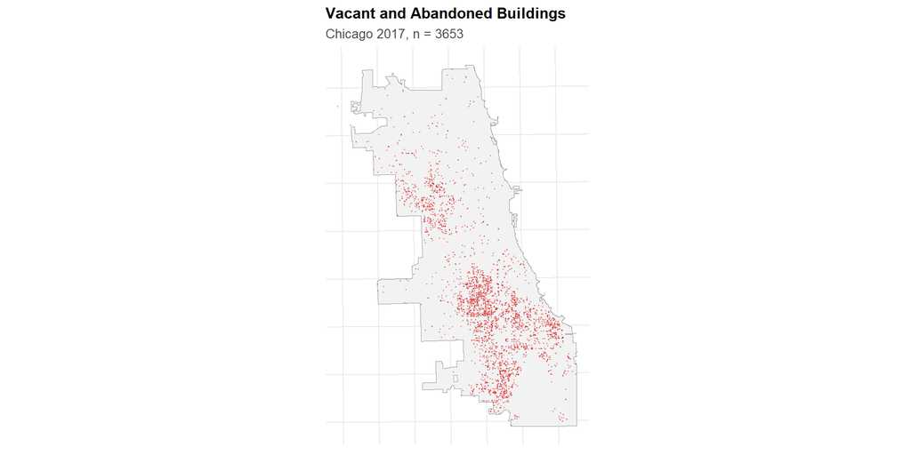

```r
# Simple point map
p1 <- ggplot() +
  geom_sf(data = chicagoBoundary, fill = "gray95", color = "gray60") +
  geom_sf(data = vacant_buildings, color = "#d62828", size = 0.2, alpha = 0.4) +
  labs(
    title = "Vacant and Abandoned Buildings",
    subtitle = paste0("Chicago 2017, n = ", nrow(vacant_buildings))
  )
p1
```

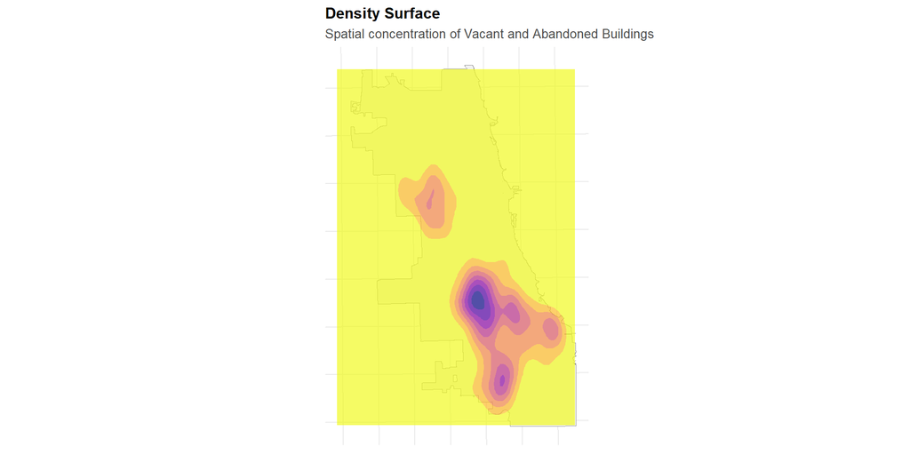

```r
# Density surface using modern syntax
p2 <- ggplot() +
  geom_sf(data = chicagoBoundary, fill = "gray95", color = "gray60") +
  geom_density_2d_filled(
    data = data.frame(st_coordinates(vacant_buildings)),
    aes(X, Y),
    alpha = 0.7,
    bins = 8
  ) +
  scale_fill_viridis_d(
    option = "plasma",
    direction = -1,
    guide = "none"
  ) +
  labs(
    title = "Density Surface",
    subtitle = "Spatial concentration of Vacant and Abandoned Buildings"
  )
p2
```

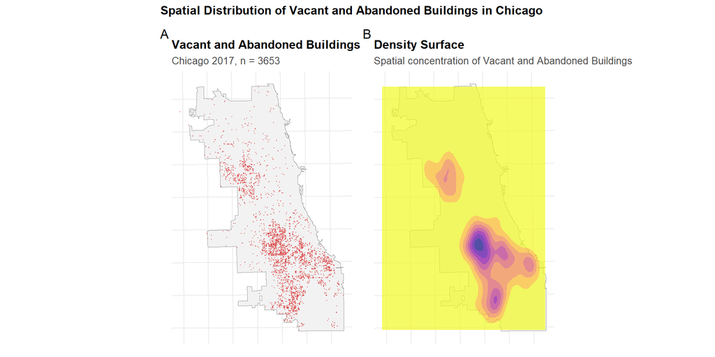

```r
# Combine plots using patchwork (modern approach)
p1 + p2 +
  plot_annotation(
    title = "Spatial Distribution of Vacant and Abandoned Buildings in Chicago",
    tag_levels = "A"
  )
```

In this first step, I loaded the 2017 Vacant and Abandoned Building Reports and mapped them across Chicago. I also created a simple density surface to get a clearer sense of where reports were concentrated. This step was important because I needed to understand the overall spatial pattern before moving into grid analysis and modeling. From the maps, Vacant and abandoned building reports are not evenly distributed across Chicago. Instead, they are concentrated mainly in the southern and western parts of the city, with a smaller cluster in the northwest. One possible explanation is that these areas may have weaker housing markets and lower levels of investment, while population loss may also have contributed to housing surplus and poor building maintenance. In addition, building age and the physical condition of the housing stock may be another important factor behind this spatial pattern. However, this distribution should not be treated as a perfect representation of actual conditions, because it may also partly reflect 311 reporting behavior as well as local enforcement and governance processes.

#### Part 2: Fishnet Grid Creation

```r
# Create a 500m x 500m fishnet grid over Chicago
cell_size <- 1640.42

fishnet <- st_make_grid(
  chicagoBoundary,
  cellsize = cell_size,
  square = TRUE
) %>%
  st_sf() %>%
  mutate(uniqueID = row_number())

# Keep only cells that intersect Chicago
fishnet <- fishnet[chicagoBoundary, ]

cat("Fishnet created successfully.\n")
```

```
Fishnet created successfully.
```

```r
cat("Number of cells:", nrow(fishnet), "\n")
```

```
Number of cells: 261
```

```r
cat("Cell area (square feet):", round(as.numeric(st_area(fishnet[1, ]))), "\n")
```

```
Cell area (square feet): 2690978
```

```r
# Join vacant building reports to fishnet cells and count reports per cell
vacant_fishnet <- st_join(vacant_buildings, fishnet, join = st_within) %>%
  st_drop_geometry() %>%
  group_by(uniqueID) %>%
  summarize(countVacant = n())

# Join counts back to the fishnet
fishnet <- fishnet %>%
  left_join(vacant_fishnet, by = "uniqueID") %>%
  mutate(countVacant = replace_na(countVacant, 0))

cat("Violation counts aggregated to fishnet cells.\n")
```

```
Violation counts aggregated to fishnet cells.
```

```r
summary(fishnet$countVacant)
```

```
   Min. 1st Qu.  Median    Mean 3rd Qu.    Max.
   0.00    0.00    3.00   13.99   16.00  136.00
```

```r
cat("Cells with zero reports:", sum(fishnet$countVacant == 0), "\n")
```

```
Cells with zero reports: 76
```

```r
cat("Percent of zero cells:", round(100 * mean(fishnet$countVacant == 0), 1), "%\n")
```

```
Percent of zero cells: 29.1 %
```

[figure not shown]

```r
# Visualize aggregated counts
ggplot() +
  geom_sf(data = fishnet, aes(fill = countVacant), color = NA) +
  geom_sf(data = chicagoBoundary, fill = NA, color = "white", linewidth = 0.8) +
  scale_fill_viridis_c(
    name = "Count",
    option = "plasma",
    trans = "sqrt",
    breaks = c(0, 1, 5, 10, 20)
  ) +
  labs(
    title = "Vacant and Abandoned Building Reports by Grid Cell",
    subtitle = "500m x 500m fishnet, Chicago 2017"
  ) +
  theme_crime()
```

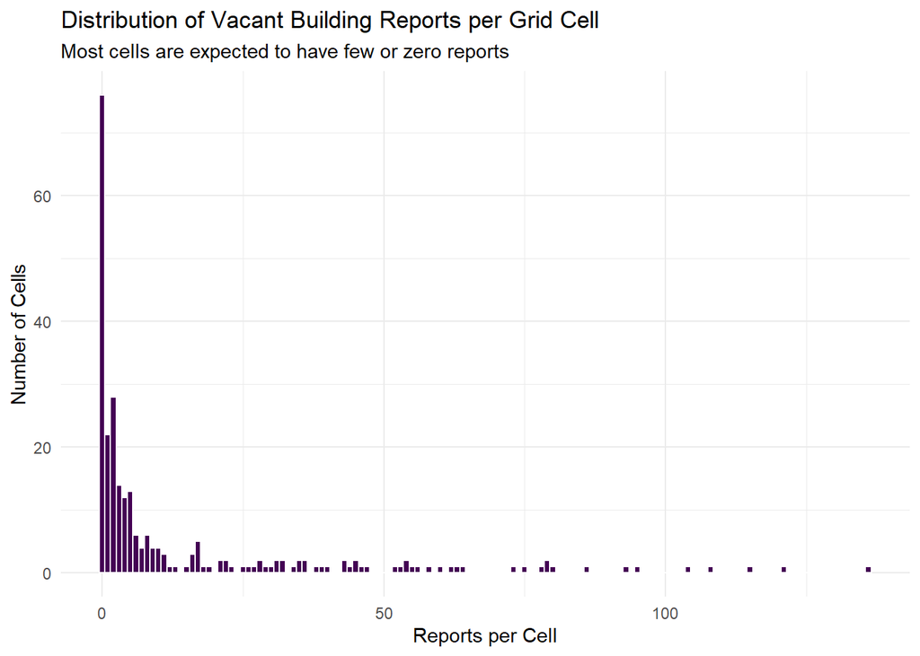

```r
# Visualize the count distribution
ggplot(fishnet, aes(x = countVacant)) +
  geom_histogram(binwidth = 1, fill = "#440154FF", color = "white") +
  labs(
    title = "Distribution of Vacant Building Reports per Grid Cell",
    subtitle = "Most cells are expected to have few or zero reports",
    x = "Reports per Cell",
    y = "Number of Cells"
  ) +
  theme_minimal()
```

#### Part 3: Spatial Features

- Calculate k-nearest neighbor features
- Perform Local Moran’s I analysis
- Identify hot spots and cold spots
- Create distance-to-hotspot measures
- Join any additional contextual data if you are looking for more to do and really get into this (e.g., demographics, land use)

```r
# Get coordinates
fishnet_coords <- st_coordinates(st_centroid(fishnet))
vacant_coords <- st_coordinates(vacant_buildings)

# Calculate k nearest neighbors and distances
nn_result <- get.knnx(vacant_coords, fishnet_coords, k = 3)

# Add to fishnet
fishnet <- fishnet %>%
  mutate(
    vacant_buildings.nn = rowMeans(nn_result$nn.dist)
  )

cat("Calculated nearest neighbor distances successfully.\n")
```

```
Calculated nearest neighbor distances successfully.
```

```r
summary(fishnet$vacant_buildings.nn)
```

```
   Min. 1st Qu.  Median    Mean 3rd Qu.    Max.
  25.44  331.92  755.03  944.04 1245.12 4645.73
```

```r
# Function to calculate Local Moran's I
calculate_local_morans <- function(data, variable, k = 5) {

  # Create spatial weights
  coords <- st_coordinates(st_centroid(data))
  neighbors <- knn2nb(knearneigh(coords, k = k))
  weights <- nb2listw(neighbors, style = "W", zero.policy = TRUE)

  # Calculate Local Moran's I
  local_moran <- localmoran(data[[variable]], weights)

  # Classify clusters
  mean_val <- mean(data[[variable]], na.rm = TRUE)

  data %>%
    mutate(
      local_i = local_moran[, 1],
      p_value = local_moran[, 5],
      is_significant = p_value < 0.05,

      moran_class = case_when(
        !is_significant ~ "Not Significant",
        local_i > 0 & .data[[variable]] > mean_val ~ "High-High",
        local_i > 0 & .data[[variable]] <= mean_val ~ "Low-Low",
        local_i < 0 & .data[[variable]] > mean_val ~ "High-Low",
        local_i < 0 & .data[[variable]] <= mean_val ~ "Low-High",
        TRUE ~ "Not Significant"
      )
    )
}

# Apply Local Moran's I to vacant building report counts
fishnet <- calculate_local_morans(fishnet, "countVacant", k = 5)
```

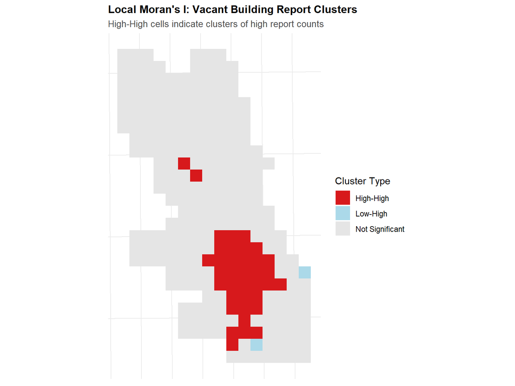

```r
ggplot() +
  geom_sf(
    data = fishnet,
    aes(fill = moran_class),
    color = NA
  ) +
  scale_fill_manual(
    values = c(
      "High-High" = "#d7191c",
      "High-Low" = "#fdae61",
      "Low-High" = "#abd9e9",
      "Low-Low" = "#2c7bb6",
      "Not Significant" = "gray90"
    ),
    name = "Cluster Type"
  ) +
  labs(
    title = "Local Moran's I: Vacant Building Report Clusters",
    subtitle = "High-High cells indicate clusters of high report counts"
  ) +
  theme_crime()
```

```r
# Get centroids of High-High cells
hotspots <- fishnet %>%
  filter(moran_class == "High-High") %>%
  st_centroid()

# Calculate distance from each cell to nearest hot spot
if (nrow(hotspots) > 0) {
  fishnet <- fishnet %>%
    mutate(
      dist_to_hotspot = as.numeric(
        st_distance(st_centroid(fishnet), hotspots %>% st_union())
      )
    )

  cat("Distance to hot spots calculated successfully.\n")
  cat("Number of hot spot cells:", nrow(hotspots), "\n")
} else {
  fishnet <- fishnet %>%
    mutate(dist_to_hotspot = 0)

  cat("No significant hot spots found.\n")
}
```

```
Distance to hot spots calculated successfully.
Number of hot spot cells: 37
```

```r
acs_context <- acs_raw %>%
  st_drop_geometry() %>%
  dplyr::select(GEOID, variable, estimate) %>%
  pivot_wider(names_from = variable, values_from = estimate) %>%
  mutate(
    poverty_rate = poverty_below / poverty_total
  )

cook_tracts <- cook_tracts %>%
  dplyr::select(GEOID) %>%
  left_join(acs_context, by = "GEOID")
```

```r
fishnet_context <- st_join(
  st_centroid(fishnet) %>% dplyr::select(uniqueID),
  cook_tracts,
  join = st_within,
  left = TRUE
) %>%
  st_drop_geometry() %>%
  dplyr::select(
    uniqueID,
    median_income,
    poverty_rate
  )

fishnet <- fishnet %>%
  left_join(fishnet_context, by = "uniqueID")

summary(fishnet$median_income)
```

```
   Min. 1st Qu.  Median    Mean 3rd Qu.    Max.    NA's
  11622   34140   48180   53435   64492  207396      16
```

```r
summary(fishnet$poverty_rate)
```

```
    Min.  1st Qu.   Median     Mean  3rd Qu.     Max.     NA's
0.004437 0.099727 0.171043 0.216308 0.305047 0.713568       16
```

In Part 3, I began to examine spatial features in order to describe the local spatial structure of vacant and abandoned building reports in more detail. I first calculated a k-nearest neighbor measure to show how close each grid cell was to nearby report locations. I then used Local Moran’s I to examine whether high-count or low-count cells were surrounded by similar cells, which helped distinguish broader spatial clustering from more isolated values. Based on that result, I identified hot spots and then calculated the distance from each cell to the nearest hot spot. In this step, I turned what had originally been a simple count map into a set of spatial variables that could be used in later regression models. My main finding was that vacant and abandoned building reports were not only unevenly distributed across the city as a whole, but also formed clear local clusters. I also tried adding contextual data, including median household income and poverty rate, to see whether demographics could improve the model. However, their effect was limited, and the explanatory power of the model still came mainly from the spatial variables rather than from the added demographic measures.

#### Part 4: Count Regression Models

- Fit Poisson regression
- Fit Negative Binomial regression
- Compare model fit (AIC)

```r
# Create clean modeling dataset
fishnet_model <- fishnet %>%
  st_drop_geometry() %>%
  dplyr::select(
    uniqueID,
    countVacant,
    vacant_buildings.nn,
    dist_to_hotspot,
    median_income,
    poverty_rate
  ) %>%
  na.omit()

cat("Modeling data prepared successfully.\n")
```

```
Modeling data prepared successfully.
```

```r
cat("Observations:", nrow(fishnet_model), "\n")
```

```
Observations: 245
```

```r
cat("Variables:", ncol(fishnet_model), "\n")
```

```
Variables: 6
```

```r
# Fit Poisson regression
model_poisson <- glm(
  countVacant ~ vacant_buildings.nn + dist_to_hotspot +
    median_income + poverty_rate,
  data = fishnet_model,
  family = "poisson"
)

summary(model_poisson)
```

```
Call:
glm(formula = countVacant ~ vacant_buildings.nn + dist_to_hotspot +
    median_income + poverty_rate, family = "poisson", data = fishnet_model)

Coefficients:
                      Estimate Std. Error z value Pr(>|z|)
(Intercept)          4.684e+00  1.085e-01  43.185  < 2e-16 ***
vacant_buildings.nn -3.026e-03  1.050e-04 -28.815  < 2e-16 ***
dist_to_hotspot     -2.130e-04  1.235e-05 -17.250  < 2e-16 ***
median_income       -6.635e-06  1.891e-06  -3.509  0.00045 ***
poverty_rate         3.073e-01  1.721e-01   1.786  0.07416 .
---
Signif. codes:  0 '***' 0.001 '**' 0.01 '*' 0.05 '.' 0.1 ' ' 1

(Dispersion parameter for poisson family taken to be 1)

    Null deviance: 7397.04  on 244  degrees of freedom
Residual deviance:  778.97  on 240  degrees of freedom
AIC: 1517.8

Number of Fisher Scoring iterations: 5
```

```r
# Calculate dispersion parameter
dispersion <- sum(residuals(model_poisson, type = "pearson")^2) /
  model_poisson$df.residual

cat("Dispersion parameter:", round(dispersion, 2), "\n")
```

```
Dispersion parameter: 3.49
```

```r
cat("Rule of thumb: > 1.5 suggests overdispersion\n")
```

```
Rule of thumb: > 1.5 suggests overdispersion
```

```r
if (dispersion > 1.5) {
  cat("Overdispersion detected. Consider Negative Binomial model.\n")
} else {
  cat("Dispersion looks acceptable for Poisson model.\n")
}
```

```
Overdispersion detected. Consider Negative Binomial model.
```

```r
# Fit Negative Binomial model
model_nb <- glm.nb(
  countVacant ~ vacant_buildings.nn + dist_to_hotspot +
    median_income + poverty_rate,
  data = fishnet_model
)

summary(model_nb)
```

```
Call:
glm.nb(formula = countVacant ~ vacant_buildings.nn + dist_to_hotspot +
    median_income + poverty_rate, data = fishnet_model, init.theta = 5.432151375,
    link = log)

Coefficients:
                      Estimate Std. Error z value Pr(>|z|)
(Intercept)          4.479e+00  2.118e-01  21.151  < 2e-16 ***
vacant_buildings.nn -3.397e-03  1.784e-04 -19.044  < 2e-16 ***
dist_to_hotspot     -1.333e-04  2.103e-05  -6.338 2.33e-10 ***
median_income       -3.344e-06  2.815e-06  -1.188    0.235
poverty_rate         4.252e-01  4.026e-01   1.056    0.291
---
Signif. codes:  0 '***' 0.001 '**' 0.01 '*' 0.05 '.' 0.1 ' ' 1

(Dispersion parameter for Negative Binomial(5.4322) family taken to be 1)

    Null deviance: 2155.73  on 244  degrees of freedom
Residual deviance:  206.42  on 240  degrees of freedom
AIC: 1154.4

Number of Fisher Scoring iterations: 1

              Theta:  5.432
          Std. Err.:  0.842

 2 x log-likelihood:  -1142.397
```

```r
cat("Poisson AIC:", round(AIC(model_poisson), 1), "\n")
```

```
Poisson AIC: 1517.8
```

```r
cat("Negative Binomial AIC:", round(AIC(model_nb), 1), "\n")
```

```
Negative Binomial AIC: 1154.4
```

```r
model_nb_spatial_only <- glm.nb(
  countVacant ~ vacant_buildings.nn + dist_to_hotspot,
  data = fishnet_model
)

AIC(model_nb_spatial_only)
```

```
[1] 1156.855
```

```r
AIC(model_nb)
```

```
[1] 1154.397
```

In Part 4, I moved from spatial description into count regression modeling. The purpose of this step was to test whether the spatial variables I created earlier were actually related to report counts in a formal statistical model, rather than only appearing related on the map. I first fitted a Poisson regression model, but the results showed clear overdispersion. Because of this, I then fitted a Negative Binomial model. In both models, the spatial variables remained the strongest and most stable predictors. I also kept median household income and poverty rate in the model to see whether neighborhood-level demographic conditions could add explanatory power, but compared with the spatial features, their effects were limited. Overall, this step showed that the distribution of vacant and abandoned building reports could be modeled statistically, but the explanatory power of the model still came mainly from spatial structure rather than from the demographic variables.

#### Part 5: Spatial Cross-Validation (2017)

- Implement Leave-One-Group-Out cross-validation on 2017 data
- Calculate and report error metrics (MAE, RMSE)

```r
# Standardize column names
names(communityAreas) <- tolower(names(communityAreas))

# Detect likely ID and name fields
area_id_col <- intersect(
  names(communityAreas),
  c("area_num_1", "area_numbe", "area_num", "commarea", "community_area")
)

name_col <- intersect(
  names(communityAreas),
  c("community", "community_name", "area_name")
)

communityAreas <- communityAreas %>%
  dplyr::select(
    CommunityArea = all_of(area_id_col[1]),
    CommunityName = all_of(name_col[1])
  )

glimpse(communityAreas)
```

```
Rows: 77
Columns: 3
$ CommunityArea <chr> "1", "2", "3", "4", "5", "6", "7", "8", "9", "10", "11",…
$ CommunityName <chr> "ROGERS PARK", "WEST RIDGE", "UPTOWN", "LINCOLN SQUARE",…
$ geometry      <MULTIPOLYGON [m]> MULTIPOLYGON (((356238.1 59..., MULTIPOLYGO…
```

```r
# Assign each fishnet cell to a community area using cell centroids
fishnet_centroids <- st_centroid(fishnet)

fishnet_groups <- st_join(
  fishnet_centroids %>% dplyr::select(uniqueID),
  communityAreas,
  join = st_within,
  left = TRUE
) %>%
  st_drop_geometry()

fishnet <- fishnet %>%
  left_join(fishnet_groups, by = "uniqueID") %>%
  filter(!is.na(CommunityArea))

cat("Community areas joined successfully.\n")
```

```
Community areas joined successfully.
```

```r
cat("Number of community areas in fishnet:", length(unique(fishnet$CommunityArea)), "\n")
```

```
Number of community areas in fishnet: 73
```

```r
cat("Number of fishnet cells retained:", nrow(fishnet), "\n")
```

```
Number of fishnet cells retained: 207
```

```r
fishnet_model_cv <- fishnet %>%
  st_drop_geometry() %>%
  dplyr::select(
    uniqueID,
    CommunityArea,
    CommunityName,
    countVacant,
    vacant_buildings.nn,
    dist_to_hotspot,
    median_income,
    poverty_rate
  ) %>%
  na.omit()

cat("Spatial CV data prepared successfully.\n")
```

```
Spatial CV data prepared successfully.
```

```r
cat("Observations:", nrow(fishnet_model_cv), "\n")
```

```
Observations: 204
```

```r
cat("Community areas:", length(unique(fishnet_model_cv$CommunityArea)), "\n")
```

```
Community areas: 73
```

```r
cv_results %>%
  arrange(desc(mae)) %>%
  kable(
    digits = 2,
    caption = "LOGO Spatial Cross-Validation Results by Community Area"
  ) %>%
  kable_styling(bootstrap_options = c("striped", "hover"))
```

LOGO Spatial Cross-Validation Results by Community Area

| fold | test_area | community | n_test | mae | rmse |
| --- | --- | --- | --- | --- | --- |
| 61 | 67 | WEST ENGLEWOOD | 2 | 52.76 | 60.31 |
| 63 | 69 | GREATER GRAND CROSSING | 3 | 31.50 | 33.04 |
| 62 | 68 | ENGLEWOOD | 3 | 26.63 | 26.67 |
| 43 | 49 | ROSELAND | 5 | 24.04 | 24.81 |
| 66 | 71 | AUBURN GRESHAM | 4 | 23.34 | 26.60 |
| 48 | 53 | WEST PULLMAN | 3 | 20.40 | 32.00 |
| 38 | 44 | CHATHAM | 3 | 19.28 | 23.01 |
| 36 | 42 | WOODLAWN | 3 | 19.01 | 24.32 |
| 12 | 20 | HERMOSA | 1 | 16.57 | 16.57 |
| 37 | 43 | SOUTH SHORE | 4 | 16.27 | 17.03 |
| 19 | 27 | EAST GARFIELD PARK | 1 | 15.72 | 15.72 |
| 57 | 61 | NEW CITY | 4 | 13.90 | 15.96 |
| 54 | 59 | MCKINLEY PARK | 1 | 13.20 | 13.20 |
| 58 | 63 | GAGE PARK | 2 | 12.56 | 14.53 |
| 40 | 46 | SOUTH CHICAGO | 2 | 12.25 | 15.44 |
| 39 | 45 | AVALON PARK | 3 | 10.66 | 12.54 |
| 42 | 48 | CALUMET HEIGHTS | 2 | 10.49 | 11.59 |
| 18 | 26 | WEST GARFIELD PARK | 1 | 9.48 | 9.48 |
| 35 | 41 | HYDE PARK | 1 | 9.30 | 9.30 |
| 53 | 58 | BRIGHTON PARK | 3 | 9.10 | 14.54 |
| 49 | 54 | RIVERDALE | 4 | 7.89 | 12.51 |
| 70 | 75 | MORGAN PARK | 4 | 7.29 | 12.22 |
| 10 | 19 | BELMONT CRAGIN | 6 | 6.40 | 8.99 |
| 41 | 47 | BURNSIDE | 1 | 6.27 | 6.27 |
| 17 | 25 | AUSTIN | 6 | 5.80 | 6.68 |
| 68 | 73 | WASHINGTON HEIGHTS | 2 | 5.57 | 7.60 |
| 56 | 60 | BRIDGEPORT | 2 | 5.08 | 6.77 |
| 16 | 24 | WEST TOWN | 3 | 4.98 | 6.59 |
| 60 | 66 | CHICAGO LAWN | 4 | 4.94 | 5.89 |
| 15 | 23 | HUMBOLDT PARK | 4 | 4.94 | 5.63 |
| 13 | 21 | AVONDALE | 3 | 4.51 | 5.46 |
| 65 | 70 | ASHBURN | 5 | 4.49 | 5.74 |
| 24 | 31 | LOWER WEST SIDE | 3 | 4.40 | 5.48 |
| 47 | 52 | EAST SIDE | 3 | 3.88 | 4.10 |
| 23 | 30 | SOUTH LAWNDALE | 5 | 3.37 | 5.01 |
| 34 | 40 | WASHINGTON PARK | 1 | 3.30 | 3.30 |
| 46 | 51 | SOUTH DEERING | 11 | 2.97 | 5.33 |
| 67 | 72 | BEVERLY | 3 | 2.96 | 4.00 |
| 30 | 37 | FULLER PARK | 2 | 2.83 | 3.39 |
| 45 | 50 | PULLMAN | 1 | 2.38 | 2.38 |
| 20 | 28 | NEAR WEST SIDE | 5 | 2.02 | 3.02 |
| 71 | 77 | EDGEWATER | 2 | 1.88 | 2.31 |
| 27 | 34 | ARMOUR SQUARE | 2 | 1.81 | 2.53 |
| 21 | 29 | NORTH LAWNDALE | 3 | 1.79 | 2.13 |
| 14 | 22 | LOGAN SQUARE | 3 | 1.46 | 1.84 |
| 59 | 65 | WEST LAWN | 3 | 1.35 | 1.47 |
| 32 | 39 | KENWOOD | 1 | 1.34 | 1.34 |
| 1 | 1 | ROGERS PARK | 2 | 1.18 | 1.63 |
| 26 | 33 | NEAR SOUTH SIDE | 1 | 1.04 | 1.04 |
| 55 | 6 | LAKE VIEW | 4 | 0.98 | 1.67 |
| 9 | 17 | DUNNING | 3 | 0.96 | 1.04 |
| 7 | 15 | PORTAGE PARK | 4 | 0.93 | 1.11 |
| 52 | 57 | ARCHER HEIGHTS | 2 | 0.86 | 0.99 |
| 3 | 11 | JEFFERSON PARK | 2 | 0.83 | 0.95 |
| 11 | 2 | WEST RIDGE | 4 | 0.54 | 0.62 |
| 5 | 13 | NORTH PARK | 4 | 0.51 | 0.59 |
| 4 | 12 | FOREST GLEN | 3 | 0.51 | 0.82 |
| 50 | 55 | HEGEWISCH | 5 | 0.50 | 0.72 |
| 2 | 10 | NORWOOD PARK | 3 | 0.48 | 0.77 |
| 22 | 3 | UPTOWN | 2 | 0.45 | 0.63 |
| 64 | 7 | LINCOLN PARK | 2 | 0.43 | 0.53 |
| 44 | 5 | NORTH CENTER | 1 | 0.36 | 0.36 |
| 51 | 56 | GARFIELD RIDGE | 3 | 0.35 | 0.35 |
| 8 | 16 | IRVING PARK | 2 | 0.34 | 0.47 |
| 6 | 14 | ALBANY PARK | 2 | 0.32 | 0.41 |
| 72 | 8 | NEAR NORTH SIDE | 3 | 0.29 | 0.41 |
| 29 | 36 | OAKLAND | 1 | 0.11 | 0.11 |
| 28 | 35 | DOUGLAS | 1 | 0.10 | 0.10 |
| 33 | 4 | LINCOLN SQUARE | 2 | 0.10 | 0.10 |
| 25 | 32 | LOOP | 1 | 0.06 | 0.06 |
| 31 | 38 | GRAND BOULEVARD | 1 | 0.02 | 0.02 |
| 69 | 74 | MOUNT GREENWOOD | 2 | 0.01 | 0.01 |
| 73 | 9 | EDISON PARK | 1 | 0.00 | 0.00 |

In Part 5, I used spatial cross-validation to test whether the model could still work outside the areas used for training. I used Community Areas as the grouping unit and applied a Leave-One-Group-Out approach. This step was important because nearby spatial units are often similar to each other, so a random split could overestimate model performance. The goal here was to see whether the model could generalize to other parts of the city. The results showed that model performance varied substantially across Community Areas. Some areas had very small prediction errors, while others had much larger ones, especially in several South and West Side communities such as West Englewood, Greater Grand Crossing, Englewood, and Roseland. This suggests that the model’s ability to transfer across space was uneven. In particular, high-cluster areas were often harder to predict precisely, even if the model could still capture the broader pattern of where reports were concentrated. I think one possible reason is that the pattern in these community areas cannot be fully learned from data in the rest of the city, which makes it harder for the model to generalize across communities.

#### Part 6: Model Evaluation

- Compare to KDE baseline

```r
# Convert vacant building reports to ppp format
vacant_ppp <- as.ppp(
  st_coordinates(vacant_buildings),
  W = as.owin(st_bbox(chicagoBoundary))
)

# Calculate KDE with 1km bandwidth
kde_vacant <- density.ppp(
  vacant_ppp,
  sigma = 1000,
  edge = TRUE
)

# Convert to terra raster
kde_raster <- rast(kde_vacant)

# Extract KDE values to fishnet cells
fishnet <- fishnet %>%
  mutate(
    kde_value = terra::extract(
      kde_raster,
      vect(fishnet),
      fun = mean,
      na.rm = TRUE
    )[, 2]
  )

cat("KDE baseline calculated successfully.\n")
```

```
KDE baseline calculated successfully.
```

```r
summary(fishnet$kde_value)
```

```
     Min.   1st Qu.    Median      Mean   3rd Qu.      Max.
4.347e-08 7.231e-07 2.392e-06 6.352e-06 9.848e-06 3.910e-05
```

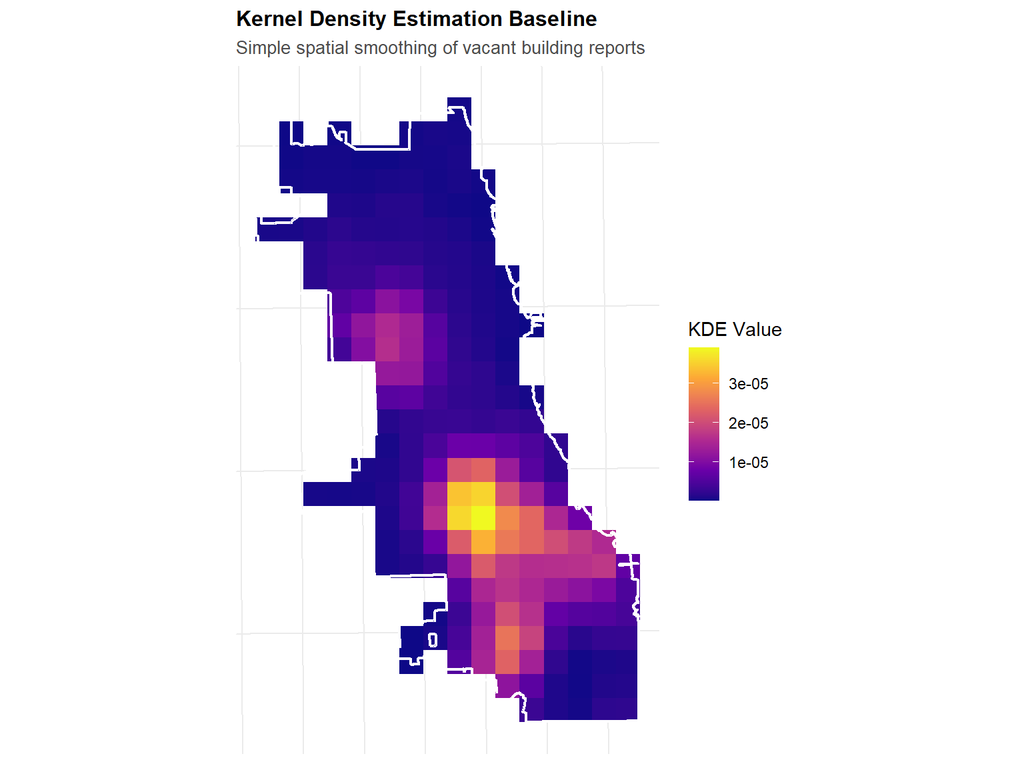

```r
ggplot() +
  geom_sf(data = fishnet, aes(fill = kde_value), color = NA) +
  geom_sf(data = chicagoBoundary, fill = NA, color = "white", linewidth = 0.8) +
  scale_fill_viridis_c(
    name = "KDE Value",
    option = "plasma"
  ) +
  labs(
    title = "Kernel Density Estimation Baseline",
    subtitle = "Simple spatial smoothing of vacant building reports"
  ) +
  theme_crime()
```

```r
# Fit final Negative Binomial model on all modeling data
final_model <- glm.nb(
  countVacant ~ vacant_buildings.nn + dist_to_hotspot +
    median_income + poverty_rate,
  data = fishnet_model
)

# Add model predictions back to fishnet
fishnet <- fishnet %>%
  mutate(
    prediction_nb = predict(final_model, newdata = fishnet_model, type = "response")[match(uniqueID, fishnet_model$uniqueID)]
  )

# Restrict KDE comparison to the same cells used by the final model
eval_ids <- fishnet_model$uniqueID

kde_sum <- fishnet %>%
  st_drop_geometry() %>%
  filter(uniqueID %in% eval_ids) %>%
  summarize(total = sum(kde_value, na.rm = TRUE)) %>%
  pull(total)

count_sum <- fishnet %>%
  st_drop_geometry() %>%
  filter(uniqueID %in% eval_ids) %>%
  summarize(total = sum(countVacant, na.rm = TRUE)) %>%
  pull(total)

fishnet <- fishnet %>%
  mutate(
    prediction_kde = if_else(
      uniqueID %in% eval_ids,
      (kde_value / kde_sum) * count_sum,
      NA_real_
    )
  )
```

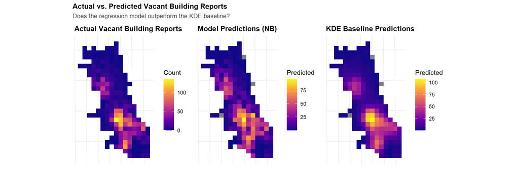

```r
p1 <- ggplot() +
  geom_sf(data = fishnet, aes(fill = countVacant), color = NA) +
  scale_fill_viridis_c(name = "Count", option = "plasma") +
  labs(title = "Actual Vacant Building Reports") +
  theme_crime()

p2 <- ggplot() +
  geom_sf(data = fishnet, aes(fill = prediction_nb), color = NA) +
  scale_fill_viridis_c(name = "Predicted", option = "plasma") +
  labs(title = "Model Predictions (NB)") +
  theme_crime()

p3 <- ggplot() +
  geom_sf(data = fishnet, aes(fill = prediction_kde), color = NA) +
  scale_fill_viridis_c(name = "Predicted", option = "plasma") +
  labs(title = "KDE Baseline Predictions") +
  theme_crime()

p1 + p2 + p3 +
  plot_annotation(
    title = "Actual vs. Predicted Vacant Building Reports",
    subtitle = "Does the regression model outperform the KDE baseline?"
  )
```

```r
comparison <- fishnet %>%
  st_drop_geometry() %>%
  filter(!is.na(prediction_nb), !is.na(prediction_kde)) %>%
  summarize(
    model_mae = mean(abs(countVacant - prediction_nb)),
    model_rmse = sqrt(mean((countVacant - prediction_nb)^2)),
    kde_mae = mean(abs(countVacant - prediction_kde)),
    kde_rmse = sqrt(mean((countVacant - prediction_kde)^2))
  )

comparison %>%
  pivot_longer(everything(), names_to = "metric", values_to = "value") %>%
  separate(metric, into = c("approach", "metric"), sep = "_") %>%
  pivot_wider(names_from = metric, values_from = value) %>%
  kable(
    digits = 2,
    caption = "Model Performance Comparison"
  ) %>%
  kable_styling(bootstrap_options = c("striped", "hover"))
```

Model Performance Comparison

| approach | mae | rmse |
| --- | --- | --- |
| model | 6.67 | 12.58 |
| kde | 5.08 | 8.71 |

In Part 6, I compared the final regression model with a simple KDE baseline to see whether the more complex model actually improved prediction. Both maps captured the main concentration of vacant and abandoned building reports, especially in the South and West parts of Chicago. However, the KDE baseline was closer to the actual pattern, and its MAE and RMSE were both lower than those of the regression model. This suggests that for a highly clustered pattern like vacant and abandoned building reports, simple spatial smoothing performed better than the count regression model. This is likely because vacant and abandoned building reports are already strongly spatially clustered, so the KDE baseline can capture that pattern directly through spatial smoothing, while the regression model uses only a limited set of variables and cannot fully capture all of the local variation.